# Basic Visualization

```python
import pandas as pd
```

```python
data=pd.read_csv("Data Latihan.csv")
data.head()
```

|  | Lokasi Dealer | Tipe | Sub Kategori | Warna | Jenis Kelamin | Kota | Propinsi | Usia | Jenis Pembayaran | Pekerjaan | Pendidikan | Harga Jual |
| --- | --- | --- | --- | --- | --- | --- | --- | --- | --- | --- | --- | --- |
| 0 | BOJONEGORO | BYSON FI (2UP1) | NAKED | HITAM | PEREMPUAN | BOJONEGORO | JAWA TIMUR | 41 | TUNAI | WIRASWASTA | SMA | 22440000 |
| 1 | JOMBANG | FINO PREMIUM FI (1YD1) | MATIC | HITAM | LAKI-LAKI | JOMBANG | JAWA TIMUR | 56 | TUNAI | PNS | SMA | 16490000 |
| 2 | MOJOKERTO | FINO PREMIUM FI (1YD1) | MATIC | HITAM | LAKI-LAKI | MOJOKERTO | JAWA TIMUR | 24 | KREDIT | PELAJAR/MAHASISWA | SMA | 16490000 |
| 3 | SURABAYA | FINO PREMIUM FI (1YD1) | MATIC | HITAM | LAKI-LAKI | SURABAYA | JAWA TIMUR | 23 | KREDIT | LAIN-LAIN | SMA | 16490000 |
| 4 | BOJONEGORO | FINO PREMIUM FI (1YD1) | MATIC | HITAM | PEREMPUAN | BOJONEGORO | JAWA TIMUR | 23 | KREDIT | KARYAWAN SWASTA | SMA | 16490000 |

```python
data.info()
```

```
<class 'pandas.core.frame.DataFrame'>
RangeIndex: 170 entries, 0 to 169
Data columns (total 12 columns):
Lokasi Dealer       170 non-null object
Tipe                170 non-null object
Sub Kategori        170 non-null object
Warna               170 non-null object
Jenis Kelamin       170 non-null object
Kota                170 non-null object
Propinsi            170 non-null object
Usia                170 non-null int64
Jenis Pembayaran    170 non-null object
Pekerjaan           170 non-null object
Pendidikan          170 non-null object
Harga Jual          170 non-null int64
dtypes: int64(2), object(10)
memory usage: 16.0+ KB
```

Dari output diatas dapat diketahui bahwa data diatas tidak terdapat missing value. Dapat diketahui juga bahwa terdapat dua jenis tipe data, yaitu:

- Object adalah tipe data yang merupakan data bukan numeric.

  > contohnya string, char, dan lainnya.
- Integer adalah tipe data numeric namun berupa bilangan bulat.

> nb: missing value merupakan data yang tidak memiliki nilai.

```python
data[['Usia','Harga Jual']].describe()
```

|  | Usia | Harga Jual |
| --- | --- | --- |
| count | 170.000000 | 1.700000e+02 |
| mean | 35.100000 | 2.290503e+07 |
| std | 11.016206 | 5.774846e+06 |
| min | 19.000000 | 1.380000e+07 |
| 25% | 26.000000 | 1.695000e+07 |
| 50% | 33.000000 | 2.582500e+07 |
| 75% | 42.750000 | 2.582500e+07 |
| max | 69.000000 | 4.735000e+07 |

```python
data.drop(['Usia','Harga Jual'], axis=1).describe()
```

[output not shown]

|  | Lokasi Dealer | Tipe | Sub Kategori | Warna | Jenis Kelamin | Kota | Propinsi | Jenis Pembayaran | Pekerjaan | Pendidikan |
| --- | --- | --- | --- | --- | --- | --- | --- | --- | --- | --- |
| count | 170 | 170 | 170 | 170 | 170 | 170 | 170 | 170 | 170 | 170 |
| unique | 10 | 19 | 5 | 8 | 2 | 11 | 1 | 2 | 7 | 6 |
| top | SURABAYA | NEW VIXION ADVANCE (2TP1) | NAKED | HITAM | LAKI-LAKI | SURABAYA | JAWA TIMUR | KREDIT | KARYAWAN SWASTA | SMA |
| freq | 44 | 52 | 69 | 64 | 119 | 41 | 170 | 102 | 62 | 153 |

## Library untuk visualisasi

```python
import matplotlib.pyplot as plt
import seaborn as sns
%matplotlib inline
plt.style.use('seaborn')
```

## Bar Plot

```python
tipe=data["Tipe"].value_counts()
tipe
```

```
NEW VIXION ADVANCE (2TP1)                  52
MIO M3 CW (2PH1)                           25
R15                                        16
NEW VIXION ADVANCE GP - MOVISTAR (2TP3)    15
ALL NEW SOUL GT (2SX1)                     15
FINO PREMIUM FI (1YD1)                      9
NMAX (2DP2)                                 9
JUPITER Z CW FI                             6
NMAX ABS 2DP1                               5
X-RIDE (2BU1)                               4
MX KING 150 (2PV1)                          4
VEGA FORCE DB CW (1FD6)                     2
R15 GP - MOVISTAR (2PK4)                    2
VEGA RR DISK BRAKE                          1
FORCE ELEGAN (1FD1)                         1
MT 25 (B041)                                1
JUPITER MX 150 (2PV2)                       1
R15 GP - TECH 3 (2PK3)                      1
BYSON FI (2UP1)                             1
Name: Tipe, dtype: int64
```

Feature tipe memiliki tipe data object. Sebelum melakukan bar plot, ubah terlebih dahulu sehingga didapatkan masing-masing feature pada tipe memiliki index tertentu berupa suatu angka.

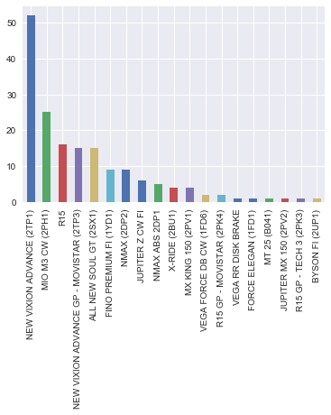

```python
tipe.plot(kind="bar")
```

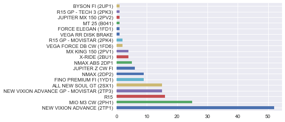

```python
tipe.plot(kind="barh")
```

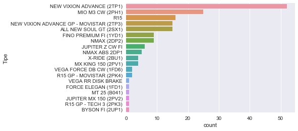

```python
sns.countplot(y='Tipe',data=data,order = data['Tipe'].value_counts().index)
```

## Pie Plot

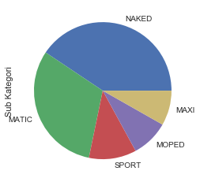

```python
data['Sub Kategori'].value_counts().plot(kind="pie")
```

Dari hasil diatas didapatkan bahwa penjualan terbanyak berdasarkan sub kategori yaitu Naked dan penjualan terendah adalah Maxi.

## Histogram

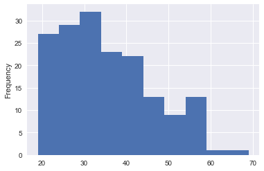

```python
data['Usia'].plot(kind='hist')
```

Dari hasil diatas didapatkan bahwa penjualan terbanyak memiliki range usia antara 25 sampai 34 tahun. Dari hasil tersebut ternyata usia 25 sampai 34 tahun merupakan usia produktif.

## Distribusi Plot

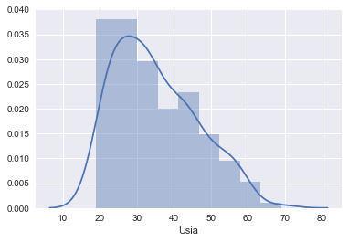

```python
sns.distplot(data["Usia"])
```

Hasil diatas menggambarkan bahwa penjualan sepeda motor terbanyak memiliki range usia antara 25 sampai 35 tahun dam mempunyai persebaran diantara range tersebut. Dari hal tersebut ternyata usia pembeli sepeda motor memiliki kecenderungan tidak berdistribusi normal.

## Boxplot

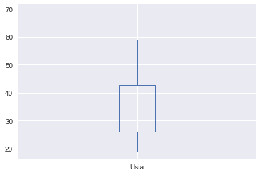

```python
data['Usia'].plot(kind='box')
```

## Violin Plot

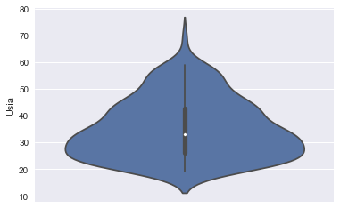

```python
sns.violinplot(y='Usia',data=data)
```

## Joint Plot

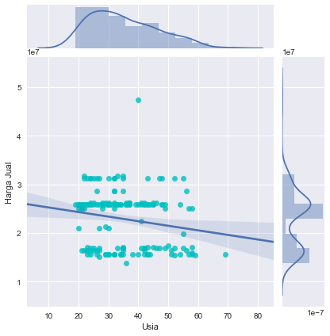

```python
sns.jointplot('Usia','Harga Jual',data=data,scatter_kws=dict(color='c'),kind='reg')
```

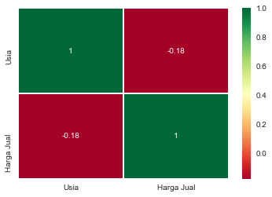

```python
sns.heatmap(data[['Usia','Harga Jual']].corr(),linewidths=.5,annot=True,cmap='RdYlGn')
```

Hasil diatas dapat memberikan gambaran hubungan antara harga jual dan usia yang dapat menggambarkan bahwa usia dan harga jual sepeda motor tidak memiliki hubungan satu sama lain, walaupun pada joint plot menunjukkan terdapat hubungan namun korelasi heatmap menggambarkan bahwa tidak terdapat hubungan antara usia dan harga jual sepeda motor